# Model diagnostics for Soil 16S 3-level occupancy model.

## Load the model and packages

```
This is posterior version 1.5.0
```

[output not shown]

## MCMC diagnostics

Basic MCMC diagnostic checks. Models with divergent transitions, or large numbers of max_treedepth errors, are likely problematic and need refinement.

```
$num_divergent
[1] 0 0 0 0

$num_max_treedepth
[1] 1000    0 1000 1000

$ebfmi
[1] 0.6740328 0.6106266 0.5608047 0.6947482
```

### Rhats

Rhat is a parameter-level summary statistic that attempts to summarise the convergence of a set of HMC/MCMC chains. A value close to 1 (approximately < 1.05) indicates chain convergence for that parameter. Below is a histogram of Rhat values for all model parameters, giving a rough at-a-glance summary of model convergence.

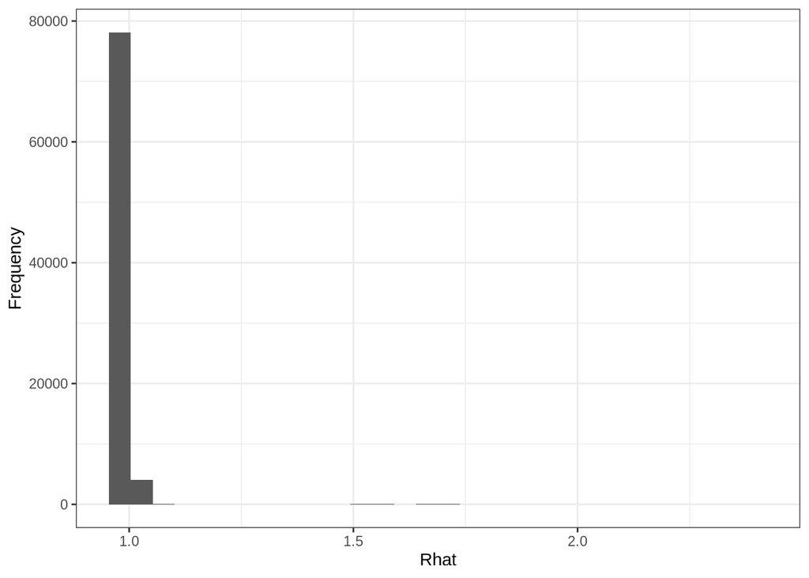

It should be noted that while this is a good rough guide, it is still important to inspect the MCMC chains more closely to gain further assurances of convergence.

### Trace plots

Below are MCMC traceplots for a selection of parameters of different types, to give a better overview of any convergence problems that may have occurred.

#### Sigmas

Site occupancy sigmas:

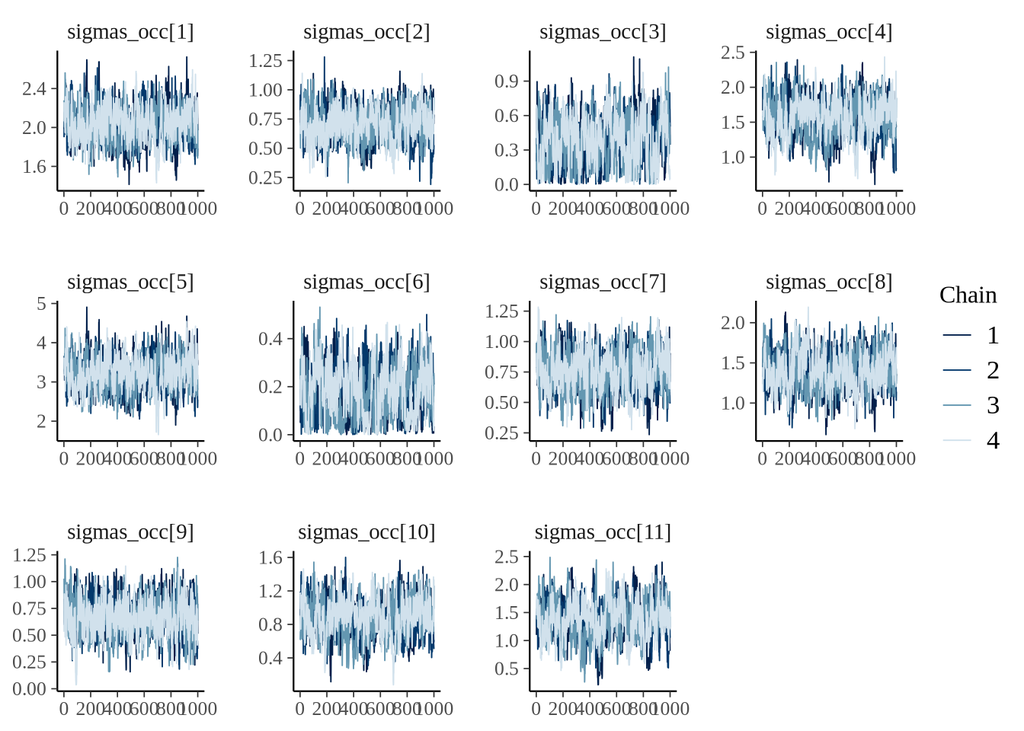

Sample occupancy sigmas:

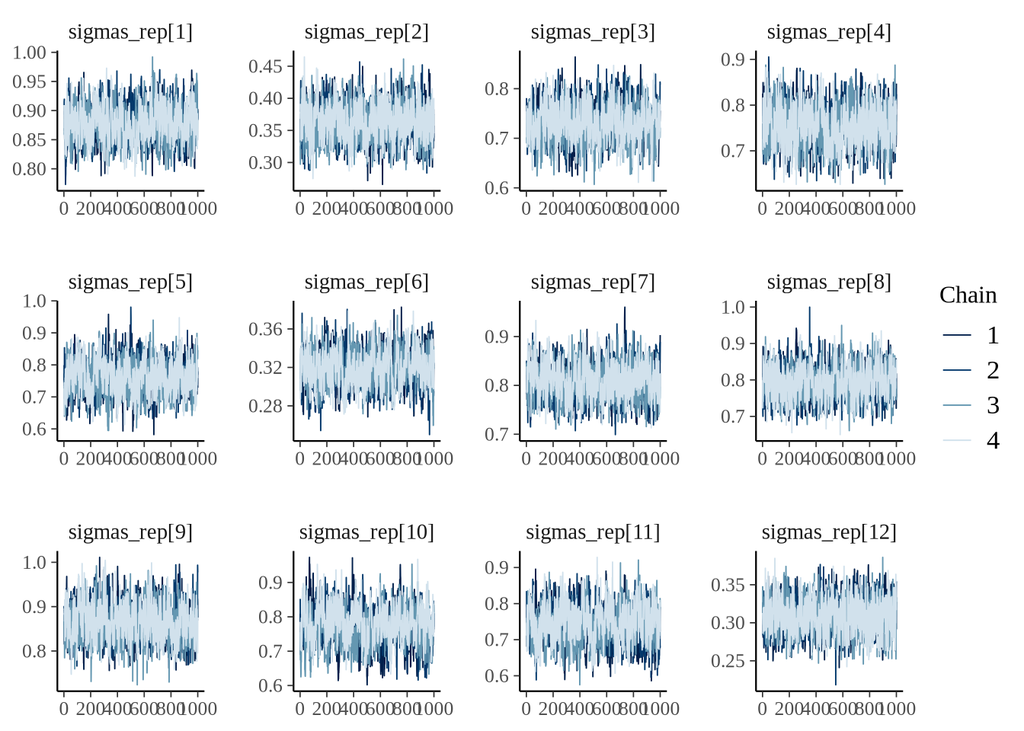

Detection sigmas:

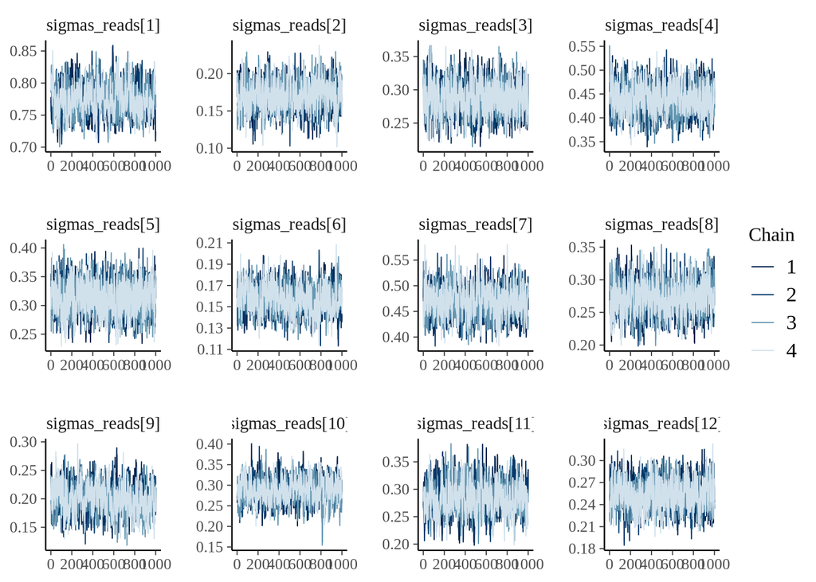

#### Fixed effects

Site occupancy:

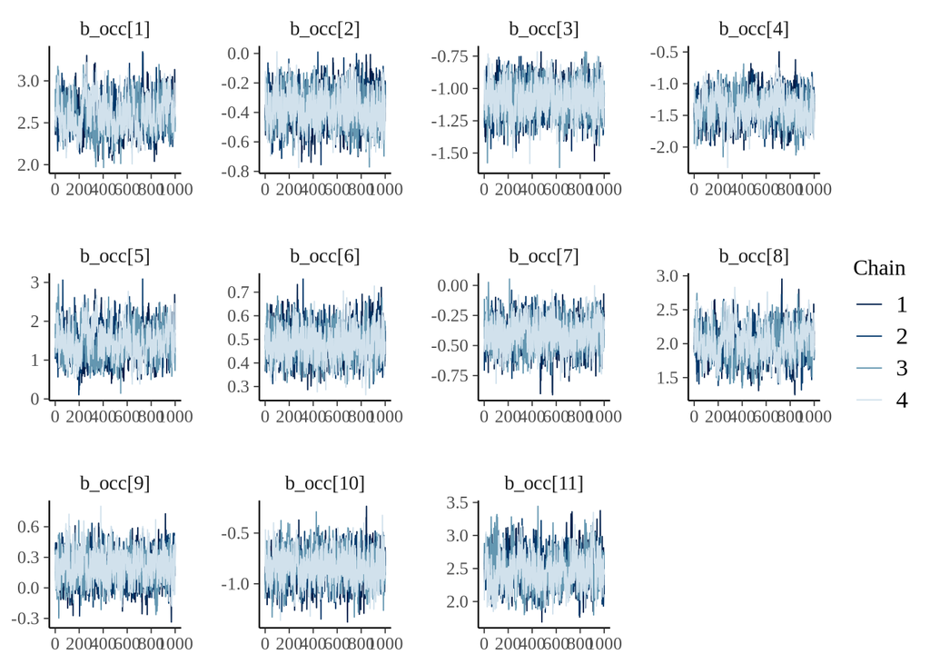

Sample occupancy:

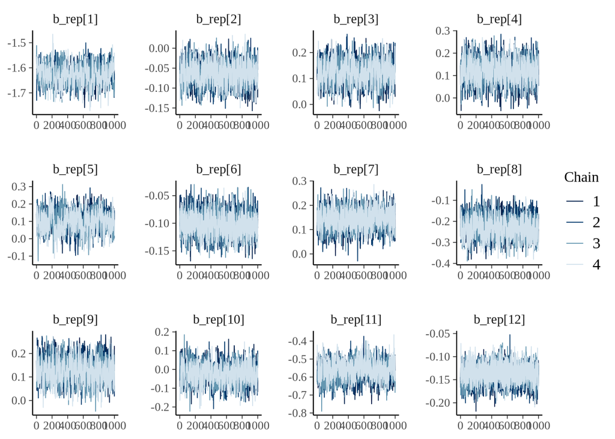

Detection:

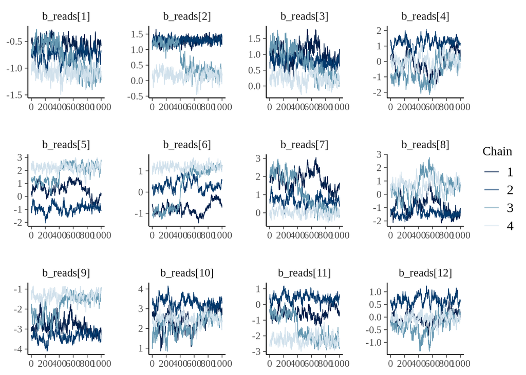

#### Species effects

Choose three random species to evaluate for:

```r
n_spp <- posterior::subset_draws(model_draws, "b_occ_species") |> as_draws_rvars() |> pluck("b_occ_species") |> ncol()
spp <- sample(n_spp, size = 3)

spp
```

```
[1]  69  76 144
```

Site occupancy:

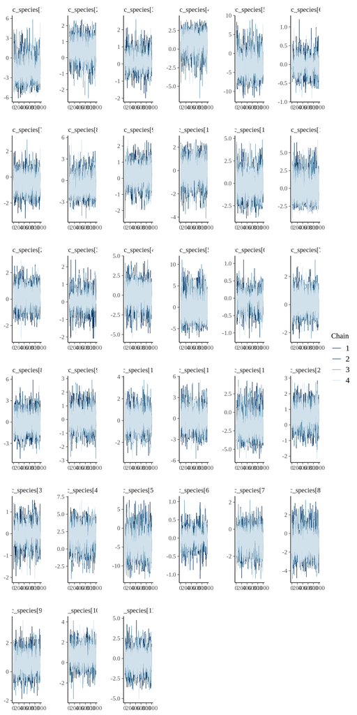

Sample occupancy:

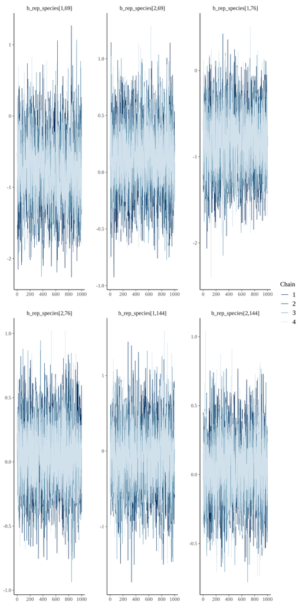

Detection:

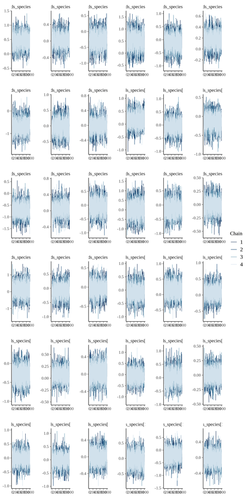

#### Dispersion

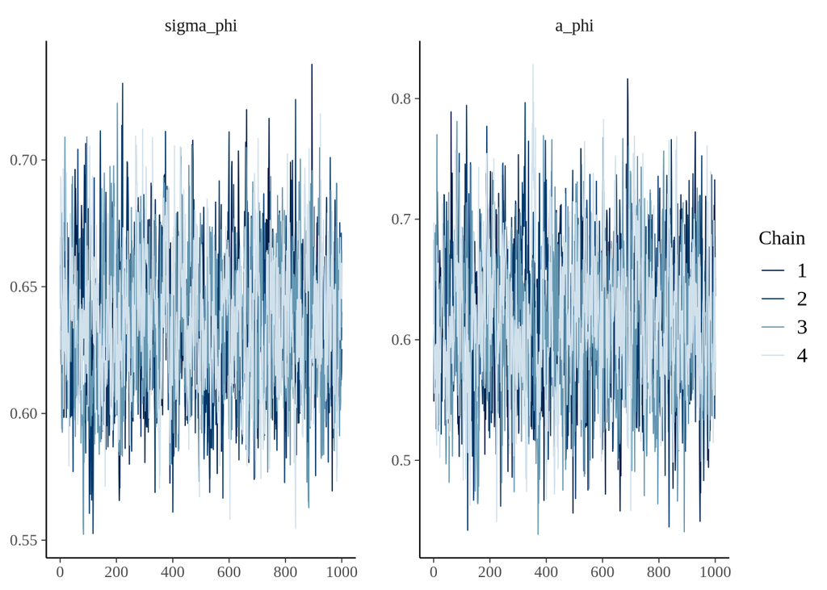

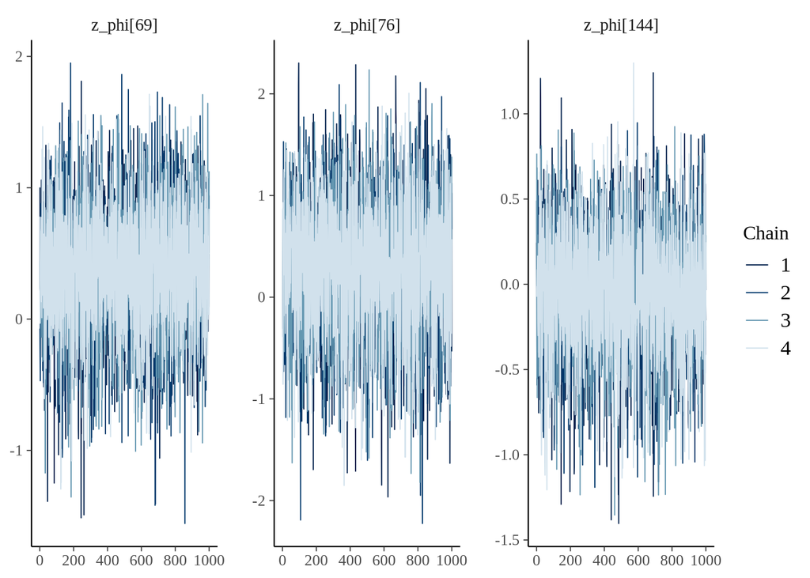

#### Size factors

```r
n_size_factors <-  posterior::subset_draws(model_draws, "SF") |> as_draws_rvars() |> pluck("SF") |> length()
sfs <- sample(n_size_factors, 10)

sfs
```

```
 [1]  36 118  85 241  10  54  69 158   3 167
```

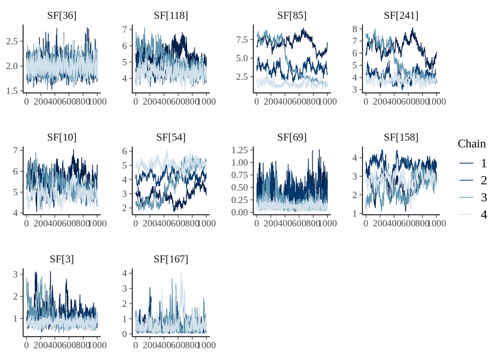

```r
posterior::subset_draws(model_draws, c("SF")) |> bayesplot::mcmc_trace(pars = vars(param_range("SF", sfs)))
```

## Leave-one-out cross-validation

Assuming MCMC diagnostics have passed, below is the leave-one-out cross validation score for the model, with moment matching.

```r
n_pars <- model_summary |>
  filter(!str_detect(variable, "species")) |>
  filter(variable != "phi") |>
  filter(variable != "log_lik")

n_pars
```

```
# A tibble: 54,583 × 10
   variable       mean   median      sd     mad       q5      q95  rhat ess_bulk
   <chr>         <dbl>    <dbl>   <dbl>   <dbl>    <dbl>    <dbl> <dbl>    <dbl>
 1 lp__       -2.80e+5 -2.80e+5 1.81e+2 1.83e+2 -2.80e+5 -2.79e+5  1.06     71.3
 2 b_occ[1]    2.59e+0  2.58e+0 2.00e-1 2.05e-1  2.28e+0  2.93e+0  1.01    302.
 3 b_occ[2]   -3.70e-1 -3.71e-1 1.15e-1 1.15e-1 -5.56e-1 -1.78e-1  1.01    746.
 4 b_occ[3]   -1.08e+0 -1.08e+0 1.24e-1 1.26e-1 -1.29e+0 -8.82e-1  1.00    902.
 5 b_occ[4]   -1.39e+0 -1.38e+0 2.30e-1 2.36e-1 -1.77e+0 -1.01e+0  1.01    438.
 6 b_occ[5]    1.44e+0  1.42e+0 4.09e-1 4.14e-1  7.95e-1  2.14e+0  1.01    363.
 7 b_occ[6]    4.84e-1  4.83e-1 6.66e-2 6.60e-2  3.78e-1  5.98e-1  1.00    732.
 8 b_occ[7]   -4.05e-1 -4.05e-1 1.21e-1 1.20e-1 -6.05e-1 -2.10e-1  1.00    834.
 9 b_occ[8]    2.00e+0  1.99e+0 2.36e-1 2.39e-1  1.63e+0  2.39e+0  1.01    349.
10 b_occ[9]    1.97e-1  1.96e-1 1.47e-1 1.49e-1 -4.04e-2  4.37e-1  1.01    935.
# ℹ 54,573 more rows
# ℹ 1 more variable: ess_tail <dbl>
```

```r
loo$estimates
```

```
           Estimate        SE
elpd_loo -246338.28 2569.8061
p_loo      13050.77  150.0258
looic     492676.55 5139.6121
```

## Goodness-of-fit

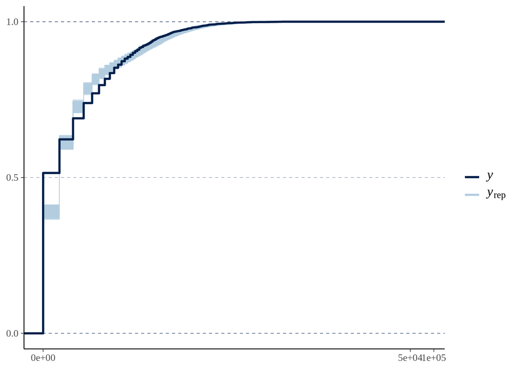

```r
Y <- model_data$Y |> {\(x) x[,,1]}() |> as.vector()
Y_rep <- model_postpreds$Y_rep |>
  t() |>
  as.vector()

len_Y <- length(Y)
max_sample <- 5000
if(len_Y > max_sample) {
  which_Y <- sample(1:len_Y, size = max_sample)
} else {
  which_Y <- 1:len_Y
}

bayesplot::ppc_ecdf_overlay(y = Y[which_Y],
                    yrep = draws_of(Y_rep[which_Y]),
                    discrete = TRUE
                    ) +
  scale_x_continuous(trans = "pseudo_log")
```

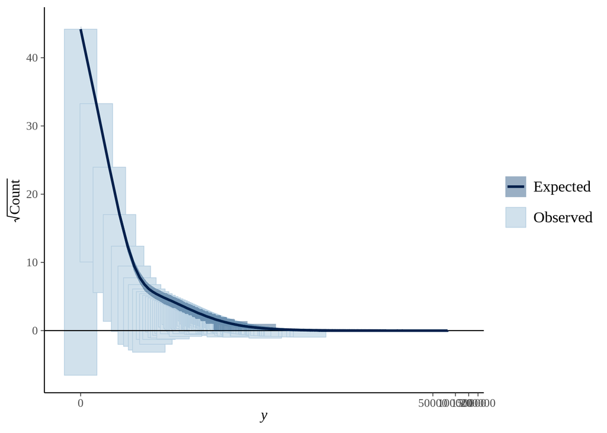

```r
bayesplot::ppc_rootogram(y = Y[which_Y],
                    yrep = draws_of(Y_rep[which_Y]),
                    style = "hanging"
                    ) +
  scale_x_continuous(trans = "pseudo_log")
```